# data 607 assignment 10

### Extra Practice with “A Tale of Two Cities” and Quanteda Sentiment

The corpus chosen is the text of “A Tale of Two Cities” by Charles Dickens. Using the gutenbergr package, download the text using gutenberg_id = 98. Modify the corpus in a similar way to the Jane Austen example. Since only 1 book is being used here, there is no need for the book column this time.

```r
remotes::install_github('quanteda/quanteda.sentiment')
library(quanteda.sentiment)
library(gutenbergr)
# The value 98 was found on the project gutenberg site.
dickens_books <- gutenberg_download(98)
```

```
## Determining mirror for Project Gutenberg from https://www.gutenberg.org/robot/harvest
```

```
## Using mirror http://aleph.gutenberg.org
```

```r
tidy_dickens_text <- dickens_books %>%
  mutate(
    linenumber = row_number(),
    chapter = cumsum(str_detect(text,
                                regex("^chapter [\\divxlc]",
                                      ignore_case = TRUE)))) %>%
  ungroup() %>%
  unnest_tokens(word, text)
```

Once again, we apply a technique from the earlier example. We do an inner join to see what matches the joy sentiments from nrc.

```r
tidy_dickens_text %>% inner_join(nrc_joy) %>% count(word, sort = TRUE)
```

```
## # A tibble: 333 × 2
##    word         n
##    <chr>    <int>
##  1 good       217
##  2 child       89
##  3 hope        84
##  4 friend      76
##  5 daughter    62
##  6 found       61
##  7 love        56
##  8 saint       56
##  9 mother      43
## 10 true        42
## # ℹ 323 more rows
```

The most recurring nrc joy word is good with 217 occurrences, followed by child, hope, friend, and daughter in order. Interestingly, good, friend, and hope are also among the most common in the book “Emma”.

We will use the bing sentiments to compare the positive and negative sentiments throughout the text.

```r
dickens_sentiment <- tidy_dickens_text %>%
  inner_join(get_sentiments("bing")) %>%
  count(index = linenumber %/% 80, sentiment) %>%
  pivot_wider(names_from = sentiment, values_from = n, values_fill = 0) %>%
  mutate(sentiment = positive - negative)
```

Repeat the process with a sentiment lexicon known as HuLiu found in the Quanteda package.

```r
quant_sent_hu <- rep('positive', each = length(data_dictionary_HuLiu$positive))
quant_sent_hu <- append(quant_sent_hu, rep('negative', each = length(data_dictionary_HuLiu$negative)))
quant_df <- data.frame(word = unlist(data_dictionary_HuLiu, use.names = FALSE), sentiment = quant_sent_hu)

dickens_quanteda_sentiment <- tidy_dickens_text %>%
  inner_join(quant_df) %>%
  count(index = linenumber %/% 80, sentiment) %>%
  pivot_wider(names_from = sentiment, values_from = n, values_fill = 0) %>%
  mutate(sentiment = positive - negative)
```

The HuLiu sentiment lexicon needed some tidying to be able to be used in the same functions. I collected the words into a column and associated the appropriate sentiment with them in a dataframe.

Next, check the sentiment plots to see how they compare.

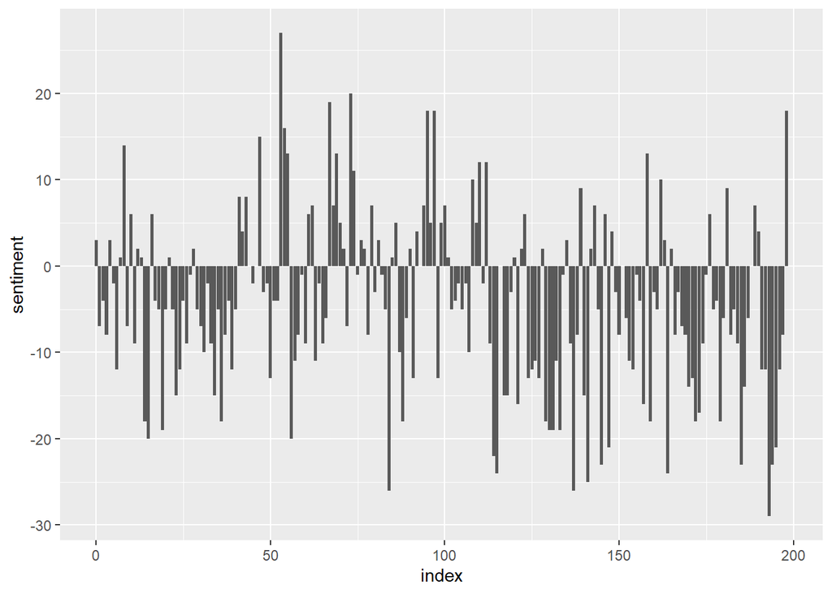

```r
ggplot(dickens_sentiment, aes(index, sentiment)) +
  geom_col(show.legend = FALSE)
```

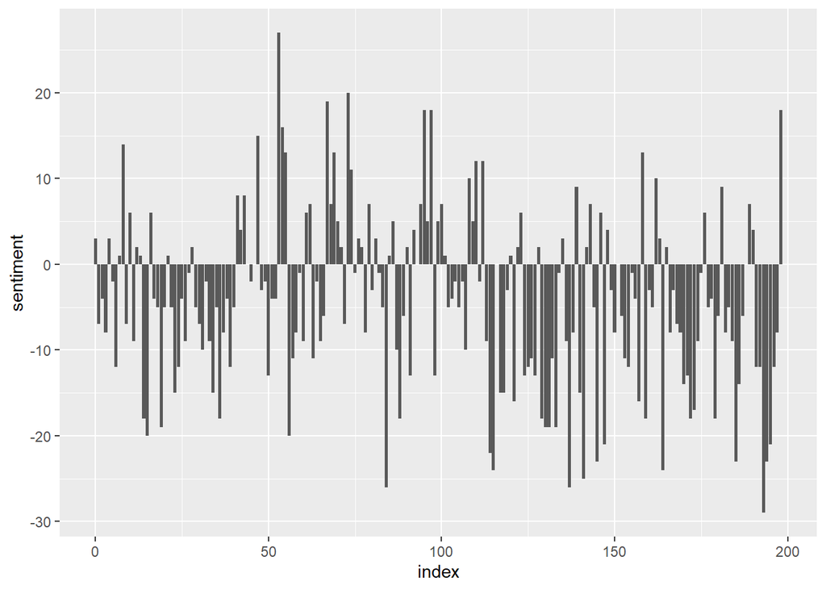

```r
ggplot(dickens_quanteda_sentiment, aes(index, sentiment)) +
  geom_col(show.legend = FALSE)
```

Oddly, the sentiment plots are identical for Bing and HuLiu. According to this article, https://medium.com/@laurenflynn1211/comparing-sentiment-analysis-dictionaries-in-r-c695fca64326, this surprising result is to be expected. They are nearly identical sentiment lexicons.

Compare all four lexicons.

```r
afinn_dickens <- tidy_dickens_text %>%
  inner_join(get_sentiments("afinn")) %>%
  group_by(index = linenumber %/% 80) %>%
  summarise(sentiment = sum(value)) %>%
  mutate(method = "AFINN")
bing_and_nrc_dickens <- bind_rows(
  tidy_dickens_text %>%
    inner_join(get_sentiments("bing")) %>%
    mutate(method = "Bing et al."),
  tidy_dickens_text %>%
    inner_join(get_sentiments("nrc") %>%
                 filter(sentiment %in% c("positive",
                                         "negative"))
    ) %>%
    mutate(method = "NRC")) %>%
  count(method, index = linenumber %/% 80, sentiment) %>%
  pivot_wider(names_from = sentiment,
              values_from = n,
              values_fill = 0) %>%
  mutate(sentiment = positive - negative)
```

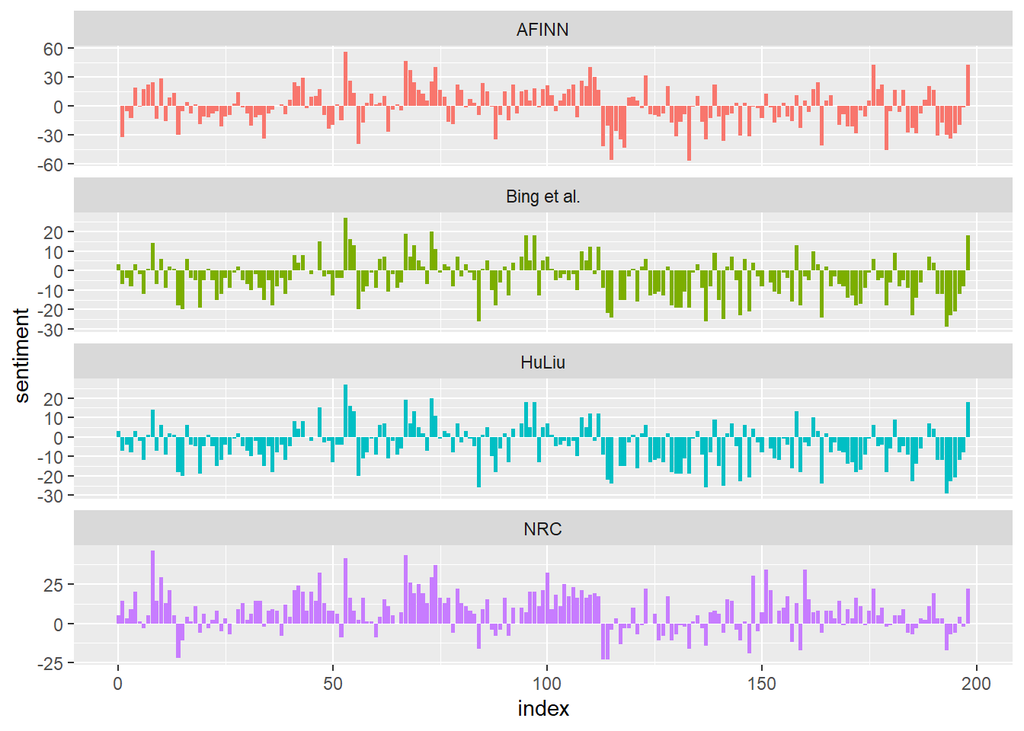

```r
dickens_quanteda_sentiment <- dickens_quanteda_sentiment %>%
    mutate(method = "HuLiu")

bind_rows(afinn_dickens,
          bing_and_nrc_dickens,
          dickens_quanteda_sentiment) %>%
  ggplot(aes(index, sentiment, fill = method)) +
  geom_col(show.legend = FALSE) +
  facet_wrap(~method, ncol = 1, scales = "free_y")
```

NRC skews much more positive than the other lexicons in the earlier story. We established the reason for this in the textbook example. This is because of the amount of positive and negative words skews more negative for Bing and HuLiu.

```r
bing_word_counts <- tidy_dickens_text %>%
  inner_join(get_sentiments("bing")) %>%
  count(word, sentiment, sort = TRUE) %>%
  ungroup()
bing_word_counts
```

```
## # A tibble: 1,870 × 3
##    word     sentiment     n
##    <chr>    <chr>     <int>
##  1 miss     negative    233
##  2 good     positive    217
##  3 like     positive    214
##  4 well     positive    179
##  5 great    positive    161
##  6 prisoner negative    115
##  7 better   positive     90
##  8 dark     negative     89
##  9 work     positive     88
## 10 poor     negative     87
## # ℹ 1,860 more rows
```

```r
huliu_word_counts <- tidy_dickens_text %>%
  inner_join(quant_df) %>%
  count(word, sentiment, sort = TRUE) %>%
  ungroup()
huliu_word_counts
```

```
## # A tibble: 1,870 × 3
##    word     sentiment     n
##    <chr>    <chr>     <int>
##  1 miss     negative    233
##  2 good     positive    217
##  3 like     positive    214
##  4 well     positive    179
##  5 great    positive    161
##  6 prisoner negative    115
##  7 better   positive     90
##  8 dark     negative     89
##  9 work     positive     88
## 10 poor     negative     87
## # ℹ 1,860 more rows
```

Once again, miss is very common and likely not meant negatively in Dickens’s works. Additionally, the HuLiu results are again identical to Bing.

Plot the word contributions for each lexicon.

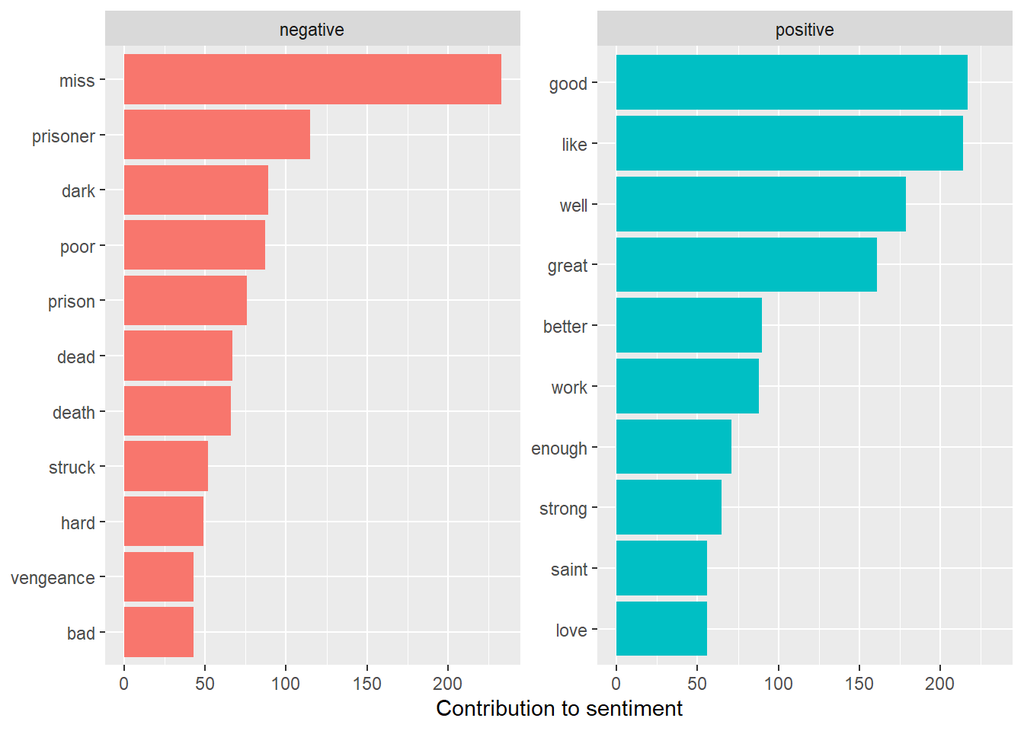

```r
bing_word_counts %>%
  group_by(sentiment) %>%
  slice_max(n, n = 10) %>%
  ungroup() %>%
  mutate(word = reorder(word, n)) %>%
  ggplot(aes(n, word, fill = sentiment)) +
  geom_col(show.legend = FALSE) +
  facet_wrap(~sentiment, scales = "free_y") +
  labs(x = "Contribution to sentiment",
       y = NULL)
```

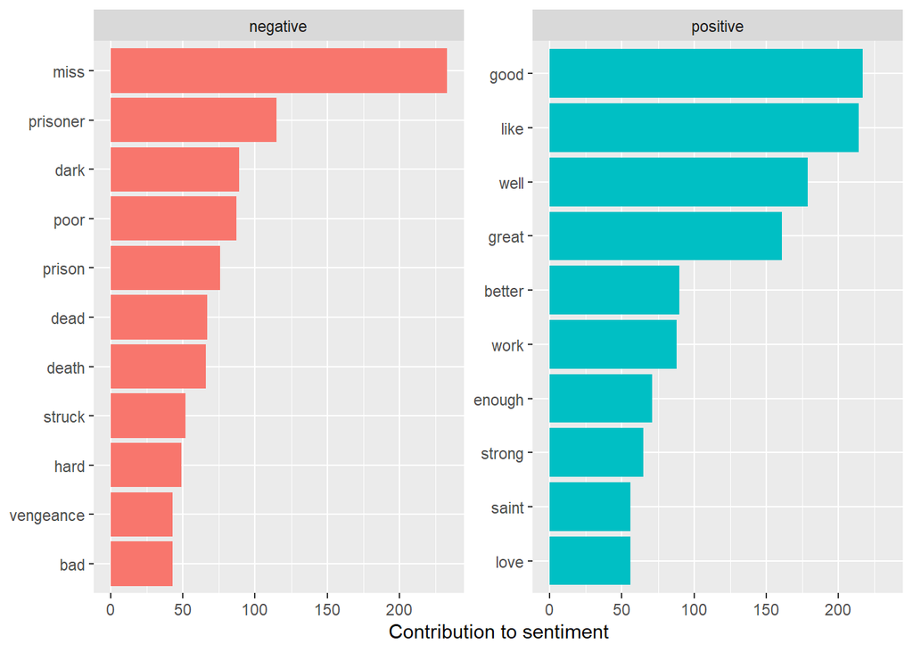

```r
huliu_word_counts %>%
  group_by(sentiment) %>%
  slice_max(n, n = 10) %>%
  ungroup() %>%
  mutate(word = reorder(word, n)) %>%
  ggplot(aes(n, word, fill = sentiment)) +
  geom_col(show.legend = FALSE) +
  facet_wrap(~sentiment, scales = "free_y") +
  labs(x = "Contribution to sentiment",
       y = NULL)
```

As there is still no difference between our lexicons, it is more interesting to note that miss is still the most common negative word, but is not as extreme as with Jane Austen’s works. Prisoner appears fairly often. Good instead of well is the most common positive word.

Let’s check the word cloud as before.

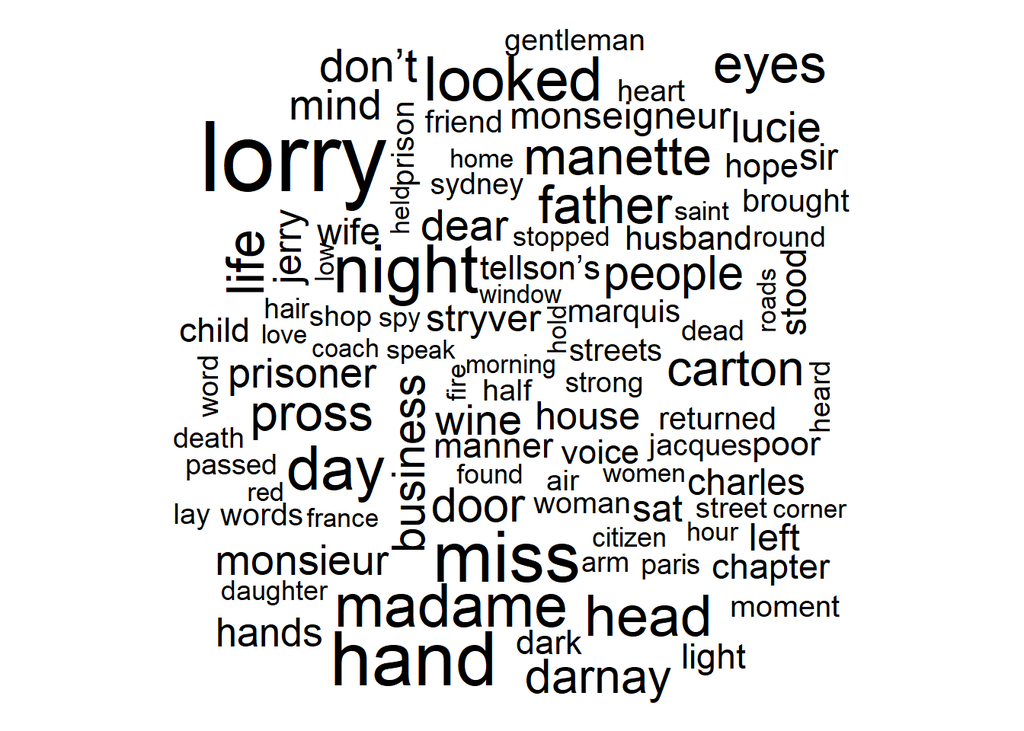

```r
tidy_dickens_text %>%
  anti_join(stop_words) %>%
  count(word) %>%
  with(wordcloud(word, n, max.words = 100))
```

Let’s redo the example word cloud while tagging positive and negative words.

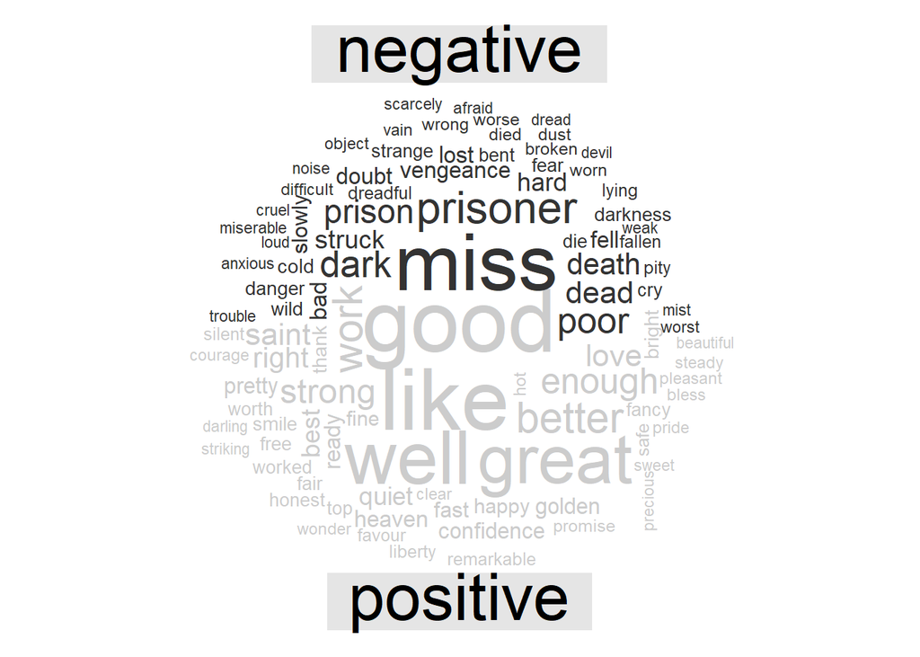

```r
set.seed(123)

tidy_dickens_text %>%
  inner_join(get_sentiments("bing")) %>%
  count(word, sentiment, sort = TRUE) %>%
  acast(word ~ sentiment, value.var = "n", fill = 0) %>%
  comparison.cloud(colors = c("gray20", "gray80"),
                   max.words = 100)
```

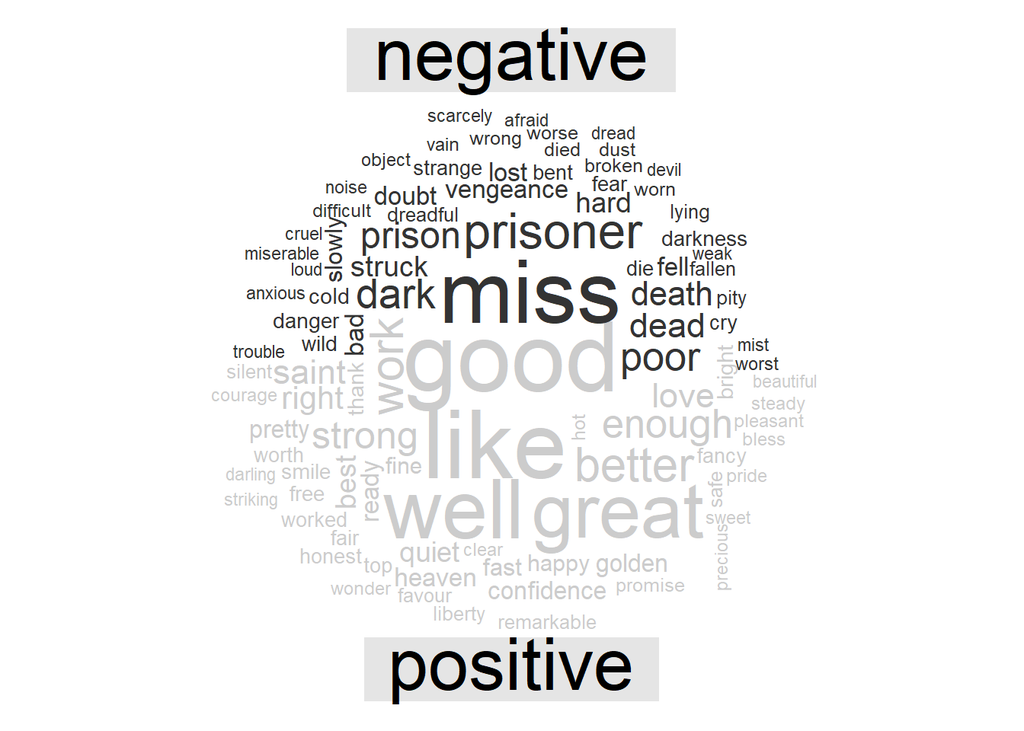

```r
set.seed(123)

tidy_dickens_text %>%
  inner_join(quant_df) %>%
  count(word, sentiment, sort = TRUE) %>%
  acast(word ~ sentiment, value.var = "n", fill = 0) %>%
  comparison.cloud(colors = c("gray20", "gray80"),
                   max.words = 100)
```

The two word clouds were separated out with seeds just to prove that they were giving identical results. Word clouds have a degree of randomness to them which can make the results look different when they actually are not.

```r
bingnegative <- get_sentiments("bing") %>%
  filter(sentiment == "negative")

wordcounts <- tidy_dickens_text %>%
  group_by(chapter) %>%
  summarize(words = n())

tidy_dickens_text %>%
  semi_join(bingnegative) %>%
  group_by(chapter) %>%
  summarize(negativewords = n()) %>%
  left_join(wordcounts, by = c("chapter")) %>%
  mutate(ratio = negativewords/words) %>%
  filter(chapter != 0) %>%
  slice_max(ratio, n = 1) %>%
  ungroup()
```

```
## # A tibble: 1 × 4
##   chapter negativewords words  ratio
##     <int>         <int> <int>  <dbl>
## 1      44           231  4665 0.0495
```

```r
huliunegative <- quant_df %>%
  filter(sentiment == "negative")

wordcounts <- tidy_dickens_text %>%
  group_by(chapter) %>%
  summarize(words = n())

tidy_dickens_text %>%
  semi_join(huliunegative) %>%
  group_by(chapter) %>%
  summarize(negativewords = n()) %>%
  left_join(wordcounts, by = c("chapter")) %>%
  mutate(ratio = negativewords/words) %>%
  filter(chapter != 0) %>%
  slice_max(ratio, n = 1) %>%
  ungroup()
```

```
## # A tibble: 1 × 4
##   chapter negativewords words  ratio
##     <int>         <int> <int>  <dbl>
## 1      44           231  4665 0.0495
```

Chapter 44 appears to be the saddest in “A Tale of Two Cities” according to both lexicons.

Let’s conduct one final test to see what was going on with the sentiment lexicons.

```r
length(quant_df$sentiment)
```

```
## [1] 6789
```

```r
length(get_sentiments('bing')$word)
```

```
## [1] 6786
```

HuLiu is 6789 words long and Bing is 6786. There apparently are differences, but very minute ones.

## Conclusions

When picking out a new corpus and an extra sentiment lexicon, I would have expected to see more differences in results than the textbook example. Selecting another prominent author from a little later than Jane Austen did not change the frequency of the word miss. Additionally, I did not realize that HuLiu was so similar to Bing until performing my analysis.

Sentiment analysis is a powerful tool to help apply feelings from words to analyze texts. They are very heavily impacted by the choices of words used to measure each text. I believe that properly matching sentiment lexicons to the right era and type of work would contribute to better analyses of the texts.